# Analysis of Riding Behaviors by Age Groups

```r
nycbikes18 <- read_csv("data/2018-citibike-tripdata.csv",
  locale = locale(tz = "America/New_York")
)
google_search <- read_csv("data/multiTimeline.csv", skip = 2)
google_search <- google_search %>% rename(no_search = "Citi Bike: (Worldwide)")
google_search <- google_search %>% mutate(weekid = 1:52)
```

# Q1: Web scraping

```r
bike_website <- read_html("https://www.citibikenyc.com/pricing")
Plan <- bike_website %>%
  html_elements("h2") %>%
  html_text()
Plan <- Plan[1:3]
Pricing <- bike_website %>%
  html_elements(".type-alpha--m") %>%
  html_text()
Minutes <- bike_website %>%
  html_elements(".spacing--half .type-alpha--s") %>%
  html_text()
Minutes <- Minutes[1:3]
Table <- tibble(Plan, Pricing, Minutes)
kable(Table)
```

| Plan | Pricing | Minutes |
| --- | --- | --- |
| Single Ride | $3.50/trip | one ride up to 30 minutes on a Classic bike. |
| Day Pass | $15/day | unlimited 30-minute rides in a 24-hour period on a Classic bike. |
| Annual Membership | $15*/month | unlimited 45-minute rides on a Classic bike. |

# Q2: Critique

The goal of the analysis was to study the different riding behaviors by age groups. I think that there was an incorrect decision in not having enough age groups and should have instead separated the ages by 0-16, 17-20, 21-25, 26-30, 31-40, 41-50, 51-60, 61+. The reasoning behind this was the age 0-16 are still dependent on their parents and therefore it makes reasonable sense to keep it this way. 17-20 is the age where people are considered ‘teenagers’ and they have more agency and independence and thus more likely to use the bikes more. 20-25, this is an age where they are becoming adults. I split the twenties into 2 as they age and more people are more likely to get other modes of transport as they age. 31-40, 41-50, 51-60 I split into a decade as their lives have become more stable and may have kids and this need less use of the bikes. At the age of 60+ it is unlikely for the elderly to be riding bikes in nyc.

There is another Critique that the age group between 0 to 14 is incorrect because. It is Prohibited for a person to be riding a bike if they are under 16 years of age. So therefore the age group should be 0 to 16.

The Rules are stated [here](https://assets.citibikenyc.com/rental-agreement.html#section_4) in Prohibited Acts.

# Q3: Polishing

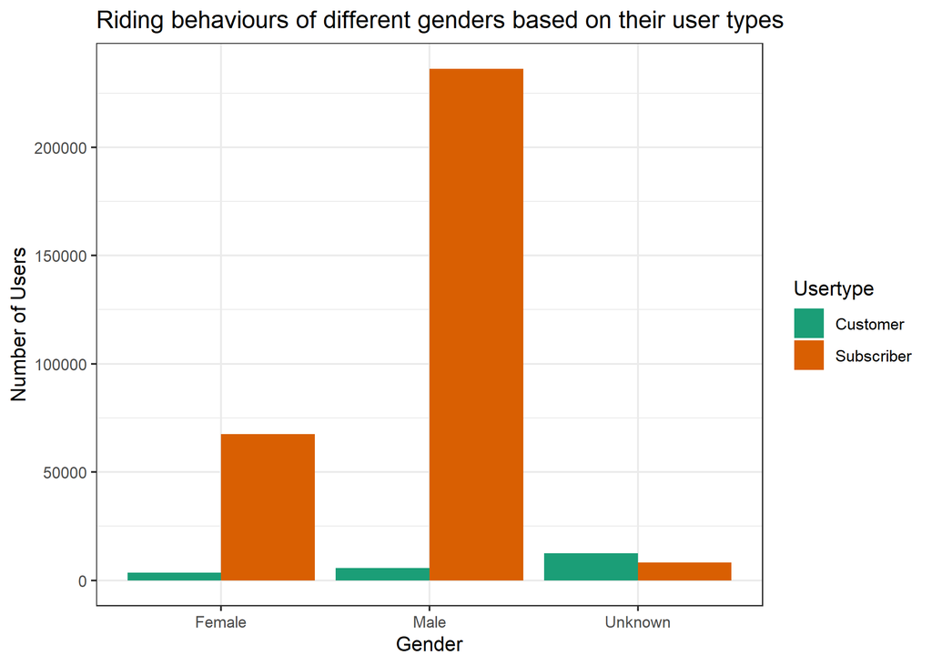

```r
nycbikes18_raw <- read_csv("data/2018-citibike-tripdata.csv")
nycbikes18 <- filter(nycbikes18_raw, birth_year > 1900) %>% mutate(gender = case_when(gender == 0 ~ "Unknown", gender == 1 ~ "Male", gender == 2 ~ "Female"))
p1 <- ggplot(nycbikes18, aes(gender, fill = usertype)) +
  geom_bar(position = "dodge") +
  labs(x = "Gender", y = "Number of Users", fill = "Usertype") +
  scale_fill_brewer(palette = "Dark2") +
  theme_bw() +
  ggtitle("Riding behaviours of different genders based on their user types")
p1
```

# Q4: Exploration

## There are 3 objectives:

### Objective 1

The first is to see which station has the most bikes to see where it is the most used and where we should add more bikes.

```r
no_bike_trips_location <- nycbikes18 %>%
  select(start_station_name, bikeid) %>%
  group_by(start_station_name) %>%
  summarise(no_of_bikes_trips = n()) %>%
  filter(no_of_bikes_trips > 0) %>%
  arrange(no_of_bikes_trips)
no_bike_trips_location
```

```
#> # A tibble: 59 x 2
#>    start_station_name   no_of_bikes_trips
#>    <chr>                            <int>
#>  1 Columbia Park                       14
#>  2 Danforth Light Rail                 19
#>  3 Bethune Center                      24
#>  4 Bayside Park                        34
#>  5 West Side Light Rail                42
#>  6 MLK Light Rail                      47
#>  7 JCBS Depot                          49
#>  8 NJCU                                49
#>  9 Garfield Ave Station               155
#> 10 Jackson Square                     344
#> # ... with 49 more rows
```

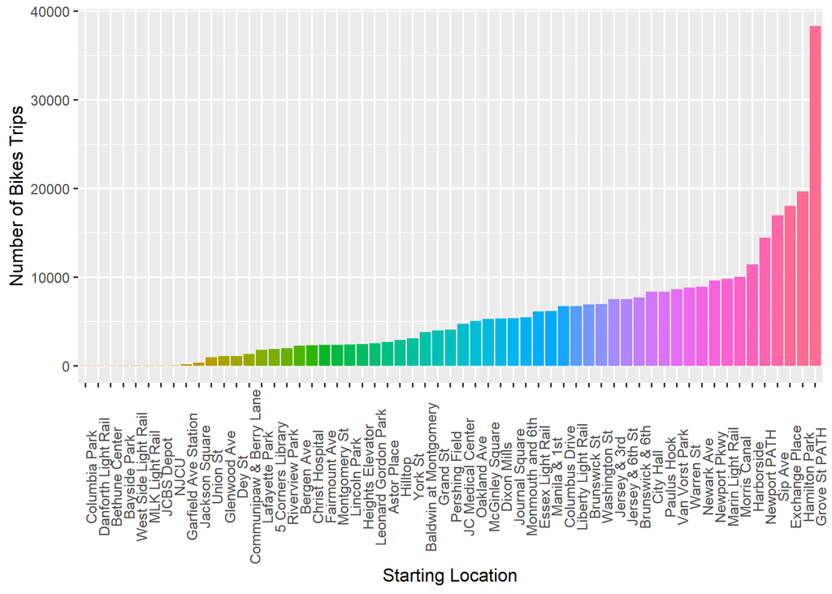

```r
p2 <- no_bike_trips_location %>%
  mutate(start_station_name = fct_reorder(start_station_name, no_of_bikes_trips)) %>%
  ggplot(aes(start_station_name, no_of_bikes_trips, fill = start_station_name)) +
  geom_col() +
  theme(axis.text.x = element_text(angle = 90), legend.position = "none") +
  labs(y = "Number of Bikes Trips", x = "Starting Location")
p2
```

The most popular place for a journey to start is at Grove St Path. This means that we should be hyper aware of when there are no more bikes left and when it needs to be repopulated. The most suitable times to be hyper aware and to check are shown in [Assignment 2 Question 10](https://stats220.earo.me/assignments/assignment2-sol/#question-10). For weekdays we look at Subscribers and for weekends we look at Customers for when the bikes need to be replenished.

### Objective 2

The second is to check how long the top 50 bikes has been ridden on to check whether we need to replace it or need to check for maintenance.

```r
trip_duration <- nycbikes18 %>%
  select(bikeid, tripduration) %>%
  group_by(bikeid) %>%
  summarise(time = round(sum(tripduration) / 60 / 60)) %>%
  arrange(desc(time)) %>%
  slice(1:50)
trip_duration
```

```
#> # A tibble: 50 x 2
#>    bikeid  time
#>     <dbl> <dbl>
#>  1  26159   655
#>  2  26262   418
#>  3  29438   400
#>  4  26210   353
#>  5  29647   339
#>  6  26211   302
#>  7  33632   299
#>  8  33658   250
#>  9  29273   243
#> 10  33615   224
#> # ... with 40 more rows
```

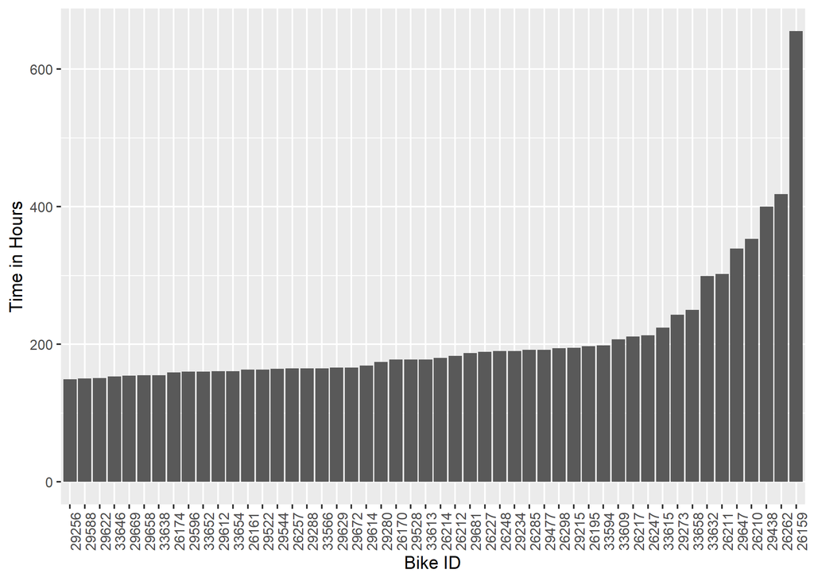

```r
p3 <- trip_duration %>%
  mutate(bikeid = as_factor(bikeid)) %>%
  mutate(bikeid = fct_reorder(bikeid, time)) %>%
  ggplot(aes(bikeid, time)) +
  geom_col() +
  theme(axis.text.x = element_text(angle = 90)) +
  labs(x = "Bike ID", y = "Time in Hours")
p3
```

Bikes that have 300 hours should be checked for maintenance and to see if it needs to be replaced.

### Objective 3

The 3rd is to check when is there the most customers interest and how would we be able to provide more amenities so that we are able to attract more tourists. I have used other sources such as Google trends to see if the interest in the number of searches corresponds to the number of customers that are cycling during the same time. And to see if the amount searched and the number that was ridden have the same rates.

```r
customer_rides <- nycbikes18 %>%
  mutate(week = week(starttime)) %>%
  filter(usertype %in% "Customer") %>%
  group_by(week) %>%
  summarise(week, no_of_rides = n()) %>%
  distinct()
customer_rides
```

```
#> # A tibble: 48 x 2
#> # Groups:   week [48]
#>     week no_of_rides
#>    <dbl>       <int>
#>  1     1           6
#>  2     2          23
#>  3     3         107
#>  4     4          42
#>  5     5          20
#>  6     6          25
#>  7     7          61
#>  8     8          71
#>  9     9          56
#> 10    10          71
#> # ... with 38 more rows
```

```r
google_search
```

```
#> # A tibble: 52 x 3
#>    Week       no_search weekid
#>    <date>         <dbl>  <int>
#>  1 2018-01-07        22      1
#>  2 2018-01-14        20      2
#>  3 2018-01-21        27      3
#>  4 2018-01-28        20      4
#>  5 2018-02-04        22      5
#>  6 2018-02-11        27      6
#>  7 2018-02-18        38      7
#>  8 2018-02-25        44      8
#>  9 2018-03-04        23      9
#> 10 2018-03-11        33     10
#> # ... with 42 more rows
```

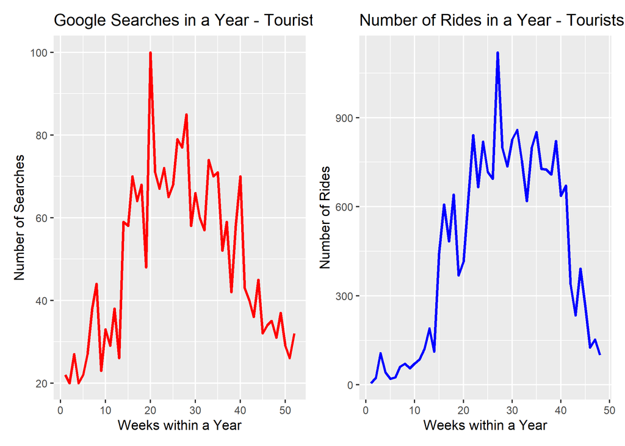

```r
p4 <- ggplot() +
  geom_line(data = customer_rides, aes(week, no_of_rides), size = 1, color = "Blue") +
  ggtitle("Number of Rides in a Year - Tourists") +
  labs(x = "Weeks within a Year", y = "Number of Rides")

p5 <- ggplot() +
  geom_line(data = google_search, aes(weekid, no_search), size = 1, color = "Red") +
  ggtitle("Google Searches in a Year - Tourists") +
  labs(x = "Weeks within a Year", y = "Number of Searches")

p6 <- p5 + p4
p6
```

As you can see the rate of searches coincides with the rate of rides. If we are able to optimize our marketing and the search engine using SEO. Then there should be an increase with the number of tourists riding Citi Bikes.

## What I have learned

- I have learned that I should not super-impose data (as shown in appendix) and have a dual Y charts as that is bad practice and it can be misleading. More information [here](https://blog.datawrapper.de/dualaxis/%3E).
- Some other things to point out is whether the objectives are asking the right questions so that Citi Bikes can be a more profitable company.

# Appendix

```r
# no_customer_rides and google search
t1 <- ggplot() +
  geom_line(data = customer_rides, aes(week, no_of_rides)) +
  geom_line(data = customer_interest_google, aes(weekid, no_trips))
t1

t2 <- ggplot() +
  geom_line(data = customer_interest_google, aes(weekid, no_trips))
t2

customer_rides_google_search <- customer_interest_google %>% full_join(customer_rides, by = c("weekid" = "week"))
customer_rides_google_search

t3 <- ggplot(data = customer_rides_google_search, aes(x = weekid)) +
  geom_line(aes(y = no_of_rides), size = 1.5, color = "Blue") +
  geom_line(aes(y = no_search), size = 1.5, color = "Red") +
  scale_y_continuous(name = "Number of Rides", sec.axis = sec_axis(~ . * 100, name = "Number of Searches"))
t3

t4 <- ggplot() +
  geom_line(data = customer_rides, aes(week, no_of_rides), size = 1, color = "Blue") +
  geom_line(data = google_search, aes(weekid, no_search), size = 1, color = "Red") +
  facet_grid(cols = vars(weekid))
t4
```